# The PyData Toolbox

### Scott Sanderson (Twitter: @scottbsanderson, GitHub: ssanderson)

### https://github.com/ssanderson/pydata-toolbox

# About Me:

[figure not shown]

- Senior Engineer at Quantopian
- Background in Mathematics and Philosophy
- **Twitter:** [@scottbsanderson](https://twitter.com/scottbsanderson)
- **GitHub:** ssanderson

## Outline

- Built-in Data Structures
- Numpy `array`
- Pandas `Series`/`DataFrame`
- Plotting and "Real-World" Analyses

# Data Structures

> Rule 5. Data dominates. If you've chosen the right data structures and organized things well, the algorithms will almost always be self-evident. Data structures, not algorithms, are central to programming.
- *Notes on Programming in C*, by Rob Pike.

# Lists

```python
l = [1, 'two', 3.0, 4, 5.0, "six"]
l
```

```
[1, 'two', 3.0, 4, 5.0, 'six']
```

```python
# Lists can be indexed like C-style arrays.
first = l[0]
second = l[1]
print("first:", first)
print("second:", second)
```

```
first: 1
second: two
```

```python
# Negative indexing gives elements relative to the end of the list.
last = l[-1]
penultimate = l[-2]
print("last:", last)
print("second to last:", penultimate)
```

```
last: six
second to last: 5.0
```

```python
# Lists can also be sliced, which makes a copy of elements between
# start (inclusive) and stop (exclusive)
sublist = l[1:3]
sublist
```

```
['two', 3.0]
```

```python
# l[:N] is equivalent to l[0:N].
first_three = l[:3]
first_three
```

```
[1, 'two', 3.0]
```

```python
# l[3:] is equivalent to l[3:len(l)].
after_three = l[3:]
after_three
```

```
[4, 5.0, 'six']
```

```python
# There's also a third parameter, "step", which gets every Nth element.
l = ['a', 'b', 'c', 'd', 'e', 'f', 'g','h']
l[1:7:2]
```

```
['b', 'd', 'f']
```

```python
# This is a cute way to reverse a list.
l[::-1]
```

```
['h', 'g', 'f', 'e', 'd', 'c', 'b', 'a']
```

```python
# Lists can be grown efficiently (in O(1) amortized time).
l = [1, 2, 3, 4, 5]
print("Before:", l)
l.append('six')
print("After:", l)
```

```
Before: [1, 2, 3, 4, 5]
After: [1, 2, 3, 4, 5, 'six']
```

```python
# Comprehensions let us perform elementwise computations.
l = [1, 2, 3, 4, 5]
[x * 2 for x in l]
```

```
[2, 4, 6, 8, 10]
```

## Review: Python Lists

- Zero-indexed sequence of arbitrary Python values.
- Slicing syntax: `l[start:stop:step]` copies elements at regular intervals from `start` to `stop`.
- Efficient (`O(1)`) appends and removes from end.
- Comprehension syntax: `[f(x) for x in l if cond(x)]`.

# Dictionaries

```python
# Dictionaries are key-value mappings.
philosophers = {'David': 'Hume', 'Immanuel': 'Kant', 'Bertrand': 'Russell'}
philosophers
```

```
{'Bertrand': 'Russell', 'David': 'Hume', 'Immanuel': 'Kant'}
```

```python
# Like lists, dictionaries are size-mutable.
philosophers['Ludwig'] = 'Wittgenstein'
philosophers
```

```
{'Bertrand': 'Russell',
 'David': 'Hume',
 'Immanuel': 'Kant',
 'Ludwig': 'Wittgenstein'}
```

```python
del philosophers['David']
philosophers
```

```
{'Bertrand': 'Russell', 'Immanuel': 'Kant', 'Ludwig': 'Wittgenstein'}
```

```python
# No slicing.
philosophers['Bertrand':'Immanuel']
```

```
---------------------------------------------------------------------------
TypeError                                 Traceback (most recent call last)
<ipython-input-16-ae3d36401614> in <module>()
      1 # No slicing.
----> 2 philosophers['Bertrand':'Immanuel']

TypeError: unhashable type: 'slice'
```

## Review: Python Dictionaries

- Unordered key-value mapping from (almost) arbitrary keys to arbitrary values.
- Efficient (`O(1)`) lookup, insertion, and deletion.
- No slicing (would require a notion of order).

[figure not shown]

```python
# Suppose we have some matrices...
a = [[1, 2, 3],
     [2, 3, 4],
     [5, 6, 7],
     [1, 1, 1]]

b = [[1, 2, 3, 4],
     [2, 3, 4, 5]]
```

```python
def matmul(A, B):
    """Multiply matrix A by matrix B."""
    rows_out = len(A)
    cols_out = len(B[0])
    out = [[0 for col in range(cols_out)] for row in range(rows_out)]

    for i in range(rows_out):
        for j in range(cols_out):
            for k in range(len(B)):
                out[i][j] += A[i][k] * B[k][j]
    return out
```

[figure not shown]

```python
%%time

matmul(a, b)
```

```
CPU times: user 0 ns, sys: 0 ns, total: 0 ns
Wall time: 21 µs
```

```
[[5, 8, 11, 14], [8, 13, 18, 23], [17, 28, 39, 50], [3, 5, 7, 9]]
```

```python
import random
def random_matrix(m, n):
    out = []
    for row in range(m):
        out.append([random.random() for _ in range(n)])
    return out

randm = random_matrix(2, 3)
randm
```

```
[[0.1284400577047189, 0.7430538602191037, 0.5982267683657111],
 [0.15040193996829998, 0.37133534561680825, 0.9791613789073683]]
```

```python
%%time
randa = random_matrix(600, 100)
randb = random_matrix(100, 600)
x = matmul(randa, randb)
```

```
CPU times: user 5.99 s, sys: 4 ms, total: 5.99 s
Wall time: 5.99 s
```

```python
# Maybe that's not that bad?  Let's try a simpler case.
def python_dot_product(xs, ys):
    return sum(x * y for x, y in zip(xs, ys))
```

```python
%%fortran
subroutine fortran_dot_product(xs, ys, result)
    double precision, intent(in) :: xs(:)
    double precision, intent(in) :: ys(:)
    double precision, intent(out) :: result

    result = sum(xs * ys)
end
```

```python
list_data = [float(i) for i in range(100000)]
array_data = np.array(list_data)
```

```python
%%time
python_dot_product(list_data, list_data)
```

```
CPU times: user 4 ms, sys: 0 ns, total: 4 ms
Wall time: 6.95 ms
```

```
333328333350000.0
```

```python
%%time
fortran_dot_product(array_data, array_data)
```

```
CPU times: user 0 ns, sys: 0 ns, total: 0 ns
Wall time: 181 µs
```

```
333328333350000.0
```

[figure not shown]

## Why is the Python Version so Much Slower?

```python
# Dynamic typing.
def mul_elemwise(xs, ys):
    return [x * y for x, y in zip(xs, ys)]

mul_elemwise([1, 2, 3, 4], [1, 2 + 0j, 3.0, 'four'])
#[type(x) for x in _]
```

```
[1, (4+0j), 9.0, 'fourfourfourfour']
```

```python
# Interpretation overhead.
source_code = 'a + b * c'
bytecode = compile(source_code, '', 'eval')
import dis; dis.dis(bytecode)
```

```
  1           0 LOAD_NAME                0 (a)
              3 LOAD_NAME                1 (b)
              6 LOAD_NAME                2 (c)
              9 BINARY_MULTIPLY
             10 BINARY_ADD
             11 RETURN_VALUE
```

## Why is the Python Version so Slow?

- Dynamic typing means that every single operation requires dispatching on the input type.
- Having an interpreter means that every instruction is fetched and dispatched at runtime.
- Other overheads:
  - Arbitrary-size integers.
  - Reference-counted garbage collection.

> This is the paradox that we have to work with when we're doing scientific or numerically-intensive Python. What makes Python fast for development -- this high-level, interpreted, and dynamically-typed aspect of the language -- is exactly what makes it slow for code execution.
- Jake VanderPlas, [*Losing Your Loops: Fast Numerical Computing with NumPy*](https://www.youtube.com/watch?v=EEUXKG97YRw)

# What Do We Do?

[figure not shown]

- Python is slow for numerical computation because it performs dynamic dispatch on every operation we perform...
- ...but often, we just want to do the same thing over and over in a loop!
- If we don't need Python's dynamicism, we don't want to pay (much) for it.
- **Idea:** Dispatch **once per operation** instead of **once per element**.

```python
import numpy as np

data = np.array([1, 2, 3, 4])
data
```

```
array([1, 2, 3, 4])
```

```python
data + data
```

```
array([2, 4, 6, 8])
```

```python
%%time
# Naive dot product
(array_data * array_data).sum()
```

```
CPU times: user 0 ns, sys: 0 ns, total: 0 ns
Wall time: 408 µs
```

```
333328333350000.0
```

```python
%%time
# Built-in dot product.
array_data.dot(array_data)
```

```
CPU times: user 0 ns, sys: 0 ns, total: 0 ns
Wall time: 162 µs
```

```
333328333350000.0
```

```python
%%time
fortran_dot_product(array_data, array_data)
```

```
CPU times: user 0 ns, sys: 0 ns, total: 0 ns
Wall time: 313 µs
```

```
333328333350000.0
```

```python
# Numpy won't allow us to write a string into an int array.
data[0] = "foo"
```

```
---------------------------------------------------------------------------
ValueError                                Traceback (most recent call last)
<ipython-input-34-c6649ce04294> in <module>()
      1 # Numpy won't allow us to write a string into an int array.
----> 2 data[0] = "foo"

ValueError: invalid literal for int() with base 10: 'foo'
```

```python
# We also can't grow an array once it's created.
data.append(3)
```

[output not shown]

```python
# We **can** reshape an array though.
two_by_two = data.reshape(2, 2)
two_by_two
```

[output not shown]

Numpy arrays are:

- Fixed-type
- Size-immutable
- Multi-dimensional
- Fast*

* If you use them correctly.

# What's in an Array?

```python
arr = np.array([1, 2, 3, 4, 5, 6], dtype='int16').reshape(2, 3)
print("Array:\n", arr, sep='')
print("===========")
print("DType:", arr.dtype)
print("Shape:", arr.shape)
print("Strides:", arr.strides)
print("Data:", arr.data.tobytes())
```

```
Array:
[[1 2 3]
 [4 5 6]]
===========
DType: int16
Shape: (2, 3)
Strides: (6, 2)
Data: b'\x01\x00\x02\x00\x03\x00\x04\x00\x05\x00\x06\x00'
```

# Core Operations

- Vectorized **ufuncs** for elementwise operations.
- Fancy indexing and masking for selection and filtering.
- Aggregations across axes.
- Broadcasting

# UFuncs

UFuncs (universal functions) are functions that operate elementwise on one or more arrays.

```python
data = np.arange(15).reshape(3, 5)
data
```

```
array([[ 0,  1,  2,  3,  4],
       [ 5,  6,  7,  8,  9],
       [10, 11, 12, 13, 14]])
```

```python
# Binary operators.
data * data
```

```
array([[  0,   1,   4,   9,  16],
       [ 25,  36,  49,  64,  81],
       [100, 121, 144, 169, 196]])
```

```python
# Unary functions.
np.sqrt(data)
```

```
array([[ 0.        ,  1.        ,  1.41421356,  1.73205081,  2.        ],
       [ 2.23606798,  2.44948974,  2.64575131,  2.82842712,  3.        ],
       [ 3.16227766,  3.31662479,  3.46410162,  3.60555128,  3.74165739]])
```

```python
# Comparison operations
(data % 3) == 0
```

```
array([[ True, False, False,  True, False],
       [False,  True, False, False,  True],
       [False, False,  True, False, False]], dtype=bool)
```

```python
# Boolean combinators.
((data % 2) == 0) & ((data % 3) == 0)
```

```
array([[ True, False, False, False, False],
       [False,  True, False, False, False],
       [False, False,  True, False, False]], dtype=bool)
```

```python
# as of python 3.5, @ is matrix-multiply
data @ data.T
```

```
array([[ 30,  80, 130],
       [ 80, 255, 430],
       [130, 430, 730]])
```

# UFuncs Review

- UFuncs provide efficient elementwise operations applied across one or more arrays.
- Arithmetic Operators (`+`, `*`, `/`)
- Comparisons (`==`, `>`, `!=`)
- Boolean Operators (`&`, `|`, `^`)
- Trigonometric Functions (`sin`, `cos`)
- Transcendental Functions (`exp`, `log`)

# Selections

We often want to perform an operation on just a subset of our data.

```python
sines = np.sin(np.linspace(0, 3.14, 10))
cosines = np.cos(np.linspace(0, 3.14, 10))
sines
```

```
array([ 0.        ,  0.34185385,  0.64251645,  0.86575984,  0.98468459,
        0.98496101,  0.8665558 ,  0.64373604,  0.34335012,  0.00159265])
```

```python
# Slicing works with the same semantics as Python lists.
sines[0]
```

```
0.0
```

```python
sines[:3]  # First three elements
```

```
array([ 0.        ,  0.34185385,  0.64251645])
```

```python
sines[5:]  # Elements from 5 on.
```

```
array([ 0.98496101,  0.8665558 ,  0.64373604,  0.34335012,  0.00159265])
```

```python
sines[::2]  # Every other element.
```

```
array([ 0.        ,  0.64251645,  0.98468459,  0.8665558 ,  0.34335012])
```

```python
# More interesting: we can index with boolean arrays to filter by a predicate.
print("sines:\n", sines)
print("sines > 0.5:\n", sines > 0.5)
print("sines[sines > 0.5]:\n", sines[sines > 0.5])
```

```
sines:
 [ 0.          0.34185385  0.64251645  0.86575984  0.98468459  0.98496101
  0.8665558   0.64373604  0.34335012  0.00159265]
sines > 0.5:
 [False False  True  True  True  True  True  True False False]
sines[sines > 0.5]:
 [ 0.64251645  0.86575984  0.98468459  0.98496101  0.8665558   0.64373604]
```

```python
# We index with lists/arrays of integers to select values at those indices.
print(sines)
sines[[0, 4, 7]]
```

```
[ 0.          0.34185385  0.64251645  0.86575984  0.98468459  0.98496101
  0.8665558   0.64373604  0.34335012  0.00159265]
```

```
array([ 0.        ,  0.98468459,  0.64373604])
```

```python
# Index arrays are often used for sorting one or more arrays.
unsorted_data = np.array([1, 3, 2, 12, -1, 5, 2])
```

```python
sort_indices = np.argsort(unsorted_data)
sort_indices
```

```
array([4, 0, 2, 6, 1, 5, 3])
```

```python
unsorted_data[sort_indices]
```

```
array([-1,  1,  2,  2,  3,  5, 12])
```

```python
market_caps = np.array([12, 6, 10, 5, 6])  # Presumably in dollars?
assets = np.array(['A', 'B', 'C', 'D', 'E'])
```

```python
# Sort assets by market cap by using the permutation that would sort market caps on ``assets``.
sort_by_mcap = np.argsort(market_caps)
assets[sort_by_mcap]
```

```
array(['D', 'B', 'E', 'C', 'A'],
      dtype='<U1')
```

```python
# Indexers are also useful for aligning data.
print("Dates:\n", repr(event_dates))
print("Values:\n", repr(event_values))
print("Calendar:\n", repr(calendar))
```

```
Dates:
 array(['2017-01-06', '2017-01-07', '2017-01-08'], dtype='datetime64[D]')
Values:
 array([10, 15, 20])
Calendar:
 array(['2017-01-03', '2017-01-04', '2017-01-05', '2017-01-06',
       '2017-01-09', '2017-01-10', '2017-01-11', '2017-01-12',
       '2017-01-13', '2017-01-17', '2017-01-18', '2017-01-19',
       '2017-01-20', '2017-01-23', '2017-01-24', '2017-01-25',
       '2017-01-26', '2017-01-27', '2017-01-30', '2017-01-31', '2017-02-01'], dtype='datetime64[D]')
```

```python
print("Raw Dates:", event_dates)
print("Indices:", calendar.searchsorted(event_dates))
print("Forward-Filled Dates:", calendar[calendar.searchsorted(event_dates)])
```

```
Raw Dates: ['2017-01-06' '2017-01-07' '2017-01-08']
Indices: [3 4 4]
Forward-Filled Dates: ['2017-01-06' '2017-01-09' '2017-01-09']
```

On multi-dimensional arrays, we can slice along each axis independently.

```python
data = np.arange(25).reshape(5, 5)
data
```

```
array([[ 0,  1,  2,  3,  4],
       [ 5,  6,  7,  8,  9],
       [10, 11, 12, 13, 14],
       [15, 16, 17, 18, 19],
       [20, 21, 22, 23, 24]])
```

```python
data[:2, :2]  # First two rows and first two columns.
```

```
array([[0, 1],
       [5, 6]])
```

```python
data[:2, [0, -1]]  # First two rows, first and last columns.
```

```
array([[0, 4],
       [5, 9]])
```

```python
data[(data[:, 0] % 2) == 0]  # Rows where the first column is divisible by two.
```

```
array([[ 0,  1,  2,  3,  4],
       [10, 11, 12, 13, 14],
       [20, 21, 22, 23, 24]])
```

# Selections Review

- Indexing with an integer removes a dimension.
- Slicing operations work on Numpy arrays the same way they do on lists.
- Indexing with a boolean array filters to True locations.
- Indexing with an integer array selects indices along an axis.
- Multidimensional arrays can apply selections independently along different axes.

## Reductions

Functions that reduce an array to a scalar.

```python
def variance(x):
    return ((x - x.mean()) ** 2).sum() / len(x)
```

```python
variance(np.random.standard_normal(1000))
```

```
1.0638195544963331
```

- `sum()` and `mean()` are both **reductions**.
- In the simplest case, we use these to reduce an entire array into a single value...

```python
data = np.arange(30)
data.mean()
```

```
14.5
```

- ...but we can do more interesting things with multi-dimensional arrays.

```python
data = np.arange(30).reshape(3, 10)
data
```

```
array([[ 0,  1,  2,  3,  4,  5,  6,  7,  8,  9],
       [10, 11, 12, 13, 14, 15, 16, 17, 18, 19],
       [20, 21, 22, 23, 24, 25, 26, 27, 28, 29]])
```

```python
data.mean()
```

```
14.5
```

```python
data.mean(axis=0)
```

```
array([ 10.,  11.,  12.,  13.,  14.,  15.,  16.,  17.,  18.,  19.])
```

```python
data.mean(axis=1)
```

```
array([  4.5,  14.5,  24.5])
```

## Reductions Review

- Reductions allow us to perform efficient aggregations over arrays.
- We can do aggregations over a single axis to collapse a single dimension.
- Many built-in reductions (`mean`, `sum`, `min`, `max`, `median`, ...).

# Broadcasting

```python
row = np.array([1, 2, 3, 4])
column = np.array([[1], [2], [3]])
print("Row:\n", row, sep='')
print("Column:\n", column, sep='')
```

```
Row:
[1 2 3 4]
Column:
[[1]
 [2]
 [3]]
```

```python
row + column
```

```
array([[2, 3, 4, 5],
       [3, 4, 5, 6],
       [4, 5, 6, 7]])
```

[figure not shown]

##### Source: http://www.scipy-lectures.org/_images/numpy_broadcasting.png

```python
# Broadcasting is particularly useful in conjunction with reductions.
print("Data:\n", data, sep='')
print("Mean:\n", data.mean(axis=0), sep='')
print("Data - Mean:\n", data - data.mean(axis=0), sep='')
```

```
Data:
[[ 0  1  2  3  4  5  6  7  8  9]
 [10 11 12 13 14 15 16 17 18 19]
 [20 21 22 23 24 25 26 27 28 29]]
Mean:
[ 10.  11.  12.  13.  14.  15.  16.  17.  18.  19.]
Data - Mean:
[[-10. -10. -10. -10. -10. -10. -10. -10. -10. -10.]
 [  0.   0.   0.   0.   0.   0.   0.   0.   0.   0.]
 [ 10.  10.  10.  10.  10.  10.  10.  10.  10.  10.]]
```

# Broadcasting Review

- Numpy operations can work on arrays of different dimensions as long as the arrays' shapes are still "compatible".
- Broadcasting works by "tiling" the smaller array along the missing dimension.
- The result of a broadcasted operation is always at least as large in each dimension as the largest array in that dimension.

# Numpy Review

- Numerical algorithms are slow in pure Python because the overhead dynamic dispatch dominates our runtime.
- Numpy solves this problem by:
  1. Imposing additional restrictions on the contents of arrays.
  2. Moving the inner loops of our algorithms into compiled C code.
- Using Numpy effectively often requires reworking an algorithms to use vectorized operations instead of for-loops, but the resulting operations are usually simpler, clearer, and faster than the pure Python equivalent.

[figure not shown]

Numpy is great for many things, but...

- Sometimes our data is equipped with a natural set of **labels**:
  - Dates/Times
  - Stock Tickers
  - Field Names (e.g. Open/High/Low/Close)
- Sometimes we have **more than one type of data** that we want to keep grouped together.
  - Tables with a mix of real-valued and categorical data.
- Sometimes we have **missing** data, which we need to ignore, fill, or otherwise work around.

[figure not shown]

Pandas extends Numpy with more complex data structures:

- `Series`: 1-dimensional, homogenously-typed, labelled array.
- `DataFrame`: 2-dimensional, semi-homogenous, labelled table.

Pandas also provides many utilities for:

- Input/Output
- Data Cleaning
- Rolling Algorithms
- Plotting

# Selection in Pandas

```python
s = pd.Series(index=['a', 'b', 'c', 'd', 'e'], data=[1, 2, 3, 4, 5])
s
```

```
a    1
b    2
c    3
d    4
e    5
dtype: int64
```

```python
# There are two pieces to a Series: the index and the values.
print("The index is:", s.index)
print("The values are:", s.values)
```

```
The index is: Index(['a', 'b', 'c', 'd', 'e'], dtype='object')
The values are: [1 2 3 4 5]
```

```python
# We can look up values out of a Series by position...
s.iloc[0]
```

```
1
```

```python
# ... or by label.
s.loc['a']
```

```
1
```

```python
# Slicing works as expected...
s.iloc[:2]
```

```
a    1
b    2
dtype: int64
```

```python
# ...but it works with labels too!
s.loc[:'c']
```

```
a    1
b    2
c    3
dtype: int64
```

```python
# Fancy indexing works the same as in numpy.
s.iloc[[0, -1]]
```

```
a    1
e    5
dtype: int64
```

```python
# As does boolean masking.
s.loc[s > 2]
```

```
c    3
d    4
e    5
dtype: int64
```

```python
# Element-wise operations are aligned by index.
other_s = pd.Series({'a': 10.0, 'c': 20.0, 'd': 30.0, 'z': 40.0})
other_s
```

```
a    10.0
c    20.0
d    30.0
z    40.0
dtype: float64
```

```python
s + other_s
```

```
a    11.0
b     NaN
c    23.0
d    34.0
e     NaN
z     NaN
dtype: float64
```

```python
# We can fill in missing values with fillna().
(s + other_s).fillna(0.0)
```

```
a    11.0
b     0.0
c    23.0
d    34.0
e     0.0
z     0.0
dtype: float64
```

```python
# Most real datasets are read in from an external file format.
aapl = pd.read_csv('AAPL.csv', parse_dates=['Date'], index_col='Date')
aapl.head()
```

| Date | Adj Close | Close | High | Low | Open | Volume |
| --- | --- | --- | --- | --- | --- | --- |
| 2010-01-04 | 27.613066 | 30.572857 | 30.642857 | 30.340000 | 30.490000 | 123432400.0 |
| 2010-01-05 | 27.660807 | 30.625713 | 30.798571 | 30.464285 | 30.657143 | 150476200.0 |
| 2010-01-06 | 27.220825 | 30.138571 | 30.747143 | 30.107143 | 30.625713 | 138040000.0 |
| 2010-01-07 | 27.170504 | 30.082857 | 30.285715 | 29.864286 | 30.250000 | 119282800.0 |
| 2010-01-08 | 27.351143 | 30.282858 | 30.285715 | 29.865715 | 30.042856 | 111902700.0 |

```python
# Slicing generalizes to two dimensions as you'd expect:
aapl.iloc[:2, :2]
```

| Date | Adj Close | Close |
| --- | --- | --- |
| 2010-01-04 | 27.613066 | 30.572857 |
| 2010-01-05 | 27.660807 | 30.625713 |

```python
aapl.loc[pd.Timestamp('2010-02-01'):pd.Timestamp('2010-02-04'), ['Close', 'Volume']]
```

| Date | Close | Volume |
| --- | --- | --- |
| 2010-02-01 | 27.818571 | 187469100.0 |
| 2010-02-02 | 27.980000 | 174585600.0 |
| 2010-02-03 | 28.461428 | 153832000.0 |
| 2010-02-04 | 27.435715 | 189413000.0 |

# Rolling Operations

[figure not shown]

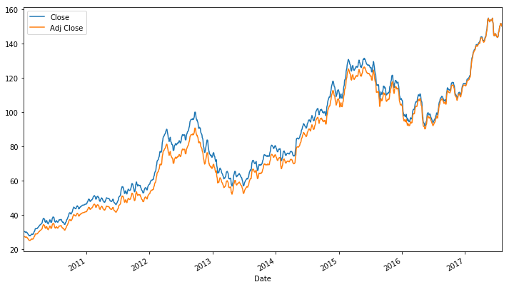

```python
aapl.rolling(5)[['Close', 'Adj Close']].mean().plot();
```

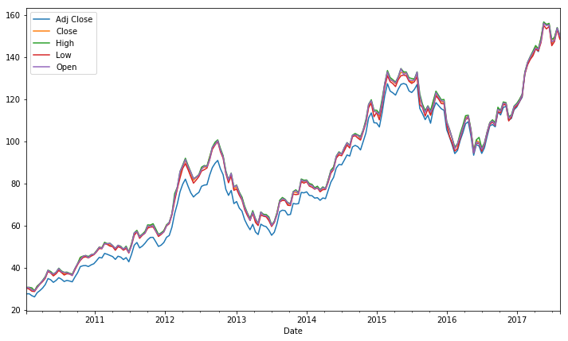

```python
# Drop `Volume`, since it's way bigger than everything else.
aapl.drop('Volume', axis=1).resample('2W').max().plot();
```

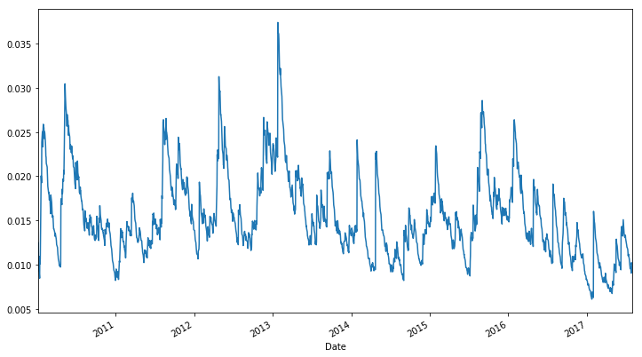

```python
# 30-day rolling exponentially-weighted stddev of returns.
aapl['Close'].pct_change().ewm(span=30).std().plot();
```

# "Real World" Data

```python
from demos.avocados import read_avocadata

avocados = read_avocadata('2014', '2016')
avocados.head()
```

|  | Date | Region | Variety | Organic | Number of Stores | Weighted Avg Price | Low Price | High Price |
| --- | --- | --- | --- | --- | --- | --- | --- | --- |
| 0 | 2014-01-03 00:00:00+00:00 | NATIONAL | HASS | False | 9184 | 0.93 | NaN | NaN |
| 1 | 2014-01-03 00:00:00+00:00 | NATIONAL | HASS | True | 872 | 1.44 | NaN | NaN |
| 2 | 2014-01-03 00:00:00+00:00 | NORTHEAST | HASS | False | 1449 | 1.08 | 0.5 | 1.67 |
| 3 | 2014-01-03 00:00:00+00:00 | NORTHEAST | HASS | True | 66 | 1.54 | 1.5 | 2.00 |
| 4 | 2014-01-03 00:00:00+00:00 | SOUTHEAST | HASS | False | 2286 | 0.98 | 0.5 | 1.99 |

```python
# Unlike numpy arrays, pandas DataFrames can have a different dtype for each column.
avocados.dtypes
```

```
Date                  datetime64[ns, UTC]
Region                             object
Variety                            object
Organic                              bool
Number of Stores                    int64
Weighted Avg Price                float64
Low Price                         float64
High Price                        float64
dtype: object
```

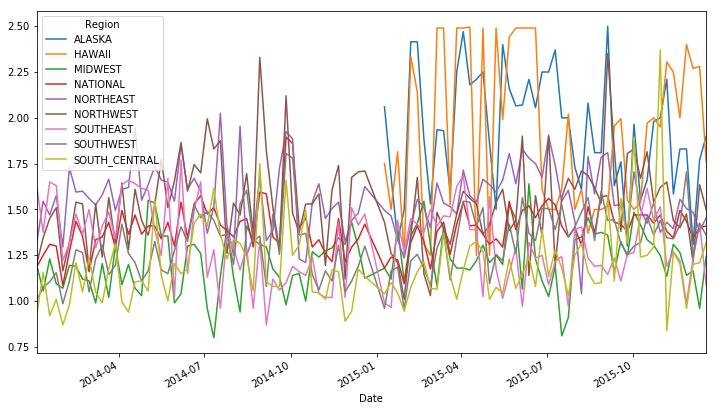

```python
# What's the regional average price of a HASS avocado every day?
hass = avocados[avocados.Variety == 'HASS']
hass.groupby(['Date', 'Region'])['Weighted Avg Price'].mean().unstack().ffill().plot();
```

```python
def _organic_spread(group):

    if len(group.columns) != 2:
        return pd.Series(index=group.index, data=0.0)

    is_organic = group.columns.get_level_values('Organic').values.astype(bool)
    organics = group.loc[:, is_organic].squeeze()
    non_organics = group.loc[:, ~is_organic].squeeze()
    diff = organics - non_organics
    return diff

def organic_spread_by_region(df):
    """What's the difference between the price of an organic
    and non-organic avocado within each region?
    """
    return (
        df
        .set_index(['Date', 'Region', 'Organic'])
         ['Weighted Avg Price']
        .unstack(level=['Region', 'Organic'])
        .ffill()
        .groupby(level='Region', axis=1)
        .apply(_organic_spread)
    )
```

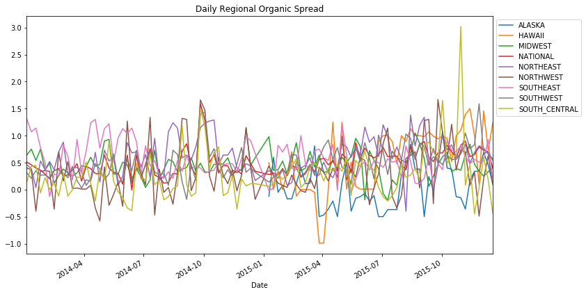

```python
organic_spread_by_region(hass).plot();
plt.gca().set_title("Daily Regional Organic Spread");
plt.legend(bbox_to_anchor=(1, 1));
```

```python
spread_correlation = organic_spread_by_region(hass).corr()
spread_correlation
```

| Region | ALASKA | HAWAII | MIDWEST | NATIONAL | NORTHEAST | NORTHWEST | SOUTHEAST | SOUTHWEST | SOUTH_CENTRAL |
| --- | --- | --- | --- | --- | --- | --- | --- | --- | --- |
| ALASKA | 1.000000 | 0.202723 | 0.175251 | 0.007844 | 0.051049 | 0.087575 | 0.129079 | -0.070868 | 0.161624 |
| HAWAII | 0.202723 | 1.000000 | -0.021116 | 0.373914 | 0.247171 | 0.341155 | 0.019388 | 0.159192 | 0.092632 |
| MIDWEST | 0.175251 | -0.021116 | 1.000000 | 0.062595 | -0.010213 | -0.043783 | 0.047437 | -0.059128 | 0.068902 |
| NATIONAL | 0.007844 | 0.373914 | 0.062595 | 1.000000 | 0.502035 | 0.579102 | -0.040539 | 0.635006 | 0.486524 |
| NORTHEAST | 0.051049 | 0.247171 | -0.010213 | 0.502035 | 1.000000 | 0.242039 | -0.236225 | 0.360389 | 0.149881 |
| NORTHWEST | 0.087575 | 0.341155 | -0.043783 | 0.579102 | 0.242039 | 1.000000 | -0.032306 | 0.165992 | 0.349935 |
| SOUTHEAST | 0.129079 | 0.019388 | 0.047437 | -0.040539 | -0.236225 | -0.032306 | 1.000000 | -0.167631 | -0.021176 |
| SOUTHWEST | -0.070868 | 0.159192 | -0.059128 | 0.635006 | 0.360389 | 0.165992 | -0.167631 | 1.000000 | 0.254504 |
| SOUTH_CENTRAL | 0.161624 | 0.092632 | 0.068902 | 0.486524 | 0.149881 | 0.349935 | -0.021176 | 0.254504 | 1.000000 |

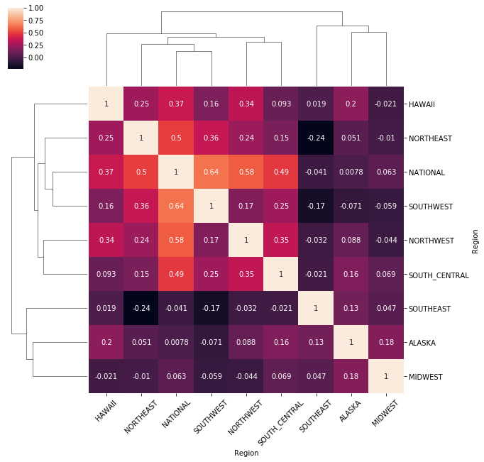

```python
import seaborn as sns
grid = sns.clustermap(spread_correlation, annot=True)
fig = grid.fig
axes = fig.axes
ax = axes[2]
ax.set_xticklabels(ax.get_xticklabels(), rotation=45);
```

# Pandas Review

- Pandas extends numpy with more complex datastructures and algorithms.
- If you understand numpy, you understand 90% of pandas.
- `groupby`, `set_index`, and `unstack` are powerful tools for working with categorical data.
- Avocado prices are surprisingly interesting :)